# Exercise 1

Felix Shier

17/01/2022

# Data Exploration and Hypothesis

```r
# imports
library(ggplot2)
```

```r
# alter plot size
knitr::opts_chunk$set(fig.width=20, fig.height=8)
```

```r
# import data
listings <- read.csv("listings.csv")
```

```r
# data head
head(listings)
```

```
##      id                                              name host_id host_name
## 1 29059                      Lovely studio Quartier Latin  125031  Maryline
## 2 29061                Maison historique - Quartier Latin  125031  Maryline
## 3 31847                             Downtown/Airport room    2319      Gail
## 4 34715                     Chez Patrac ! MÃ©tro Beaubien  149769     Alain
## 5 36301                 Romantic & peaceful Plateau  loft  381468    Sylvie
## 6 38118 Beautiful room  with a balcony in front of a parc  163569        M.
##   neighbourhood_group             neighbourhood latitude longitude
## 1                  NA               Ville-Marie 45.51939 -73.56482
## 2                  NA               Ville-Marie 45.51929 -73.56493
## 3                  NA              Le Sud-Ouest 45.48467 -73.57995
## 4                  NA Rosemont-La Petite-Patrie 45.53818 -73.60360
## 5                  NA     Le Plateau-Mont-Royal 45.53026 -73.58413
## 6                  NA               Ville-Marie 45.52699 -73.55840
##         room_type price minimum_nights number_of_reviews last_review
```

[output cut: 20 more lines]

## RQ1: Statistical Summary

In the summary statistics below, we can see some interesting things about the listing price column in the dataset. Specifically, we can see that the mean price of 125.6 is significantly higher than the median price of 85.0 which implies there are some outliers in the dataset which are skewing the data. Furthermore, we can see that the max price of 13,294.0 is significantly higher than the third quartile price of 130.0 which confirms that there are outliers in the dataset.

```r
# summary statistics
summary(listings$price)
```

```
##    Min. 1st Qu.  Median    Mean 3rd Qu.    Max.
##     0.0    52.0    85.0   125.6   130.0 13294.0
```

```r
# find number of missing listing prices
sum(is.na(listings$price))
```

```
## [1] 0
```

Additionally, we can see that there are no missing listing prices in the dataset.

We can get a better sense of the listing price data that we are working with by plotting the histogram of the listing prices.

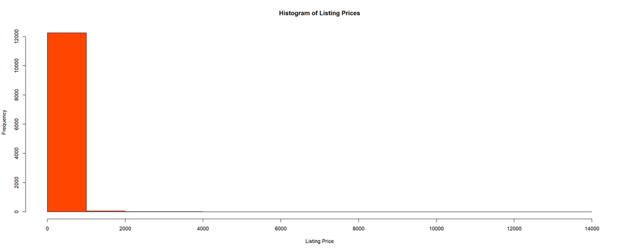

```r
# plot histogram of all listing prices
hist(listings$price,
     main = "Histogram of Listing Prices",
     xlab = "Listing Price",
     ylab = "Frequency",
     col = "orangered")
```

Actually, it turns out that the histogram in that view is not so useful after all. Perhaps by looking at different percentiles of the listing price data we can get a better understanding of the distribution of the data that we are working with.

```r
# 90, 99, 99.9 percentiles
quantile(listings$price, c(.9, .99, .999))
```

```
##   90%   99% 99.9%
##   214   900  2499
```

As seen above, 90% of the listing prices are below 214, 99% of the listing prices are below 900, and 99.9% of the listing prices are below 2499. Lets look at the histogram for each of these percentiles to once again get a better understanding of the distribution of the data that we are working with.

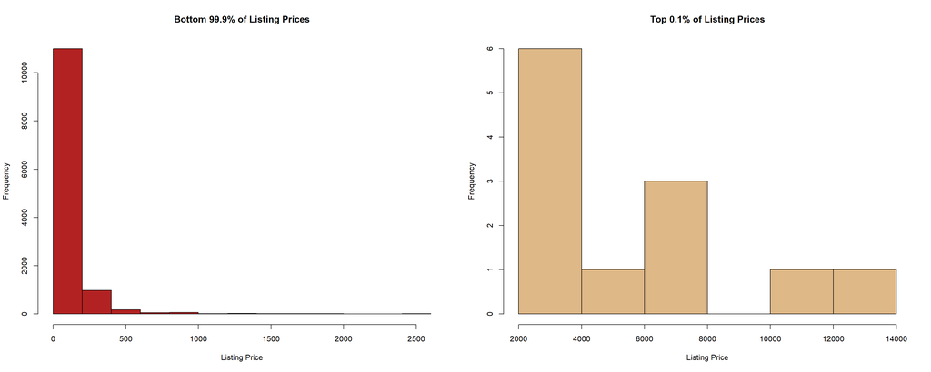

```r
# create 1x2 figure
par(mfrow=c(1,2))

# plot histogram of bottom 99.9% of listing prices
hist(listings$price[listings$price <= 2499],
     main = "Bottom 99.9% of Listing Prices",
     xlab = "Listing Price",
     ylab = "Frequency",
     col = "firebrick")

# plot histogram of top 0.1% of listing prices
hist(listings$price[listings$price > 2499],
     main = "Top 0.1% of Listing Prices",
     xlab = "Listing Price",
     ylab = "Frequency",
     col = "burlywood")
```

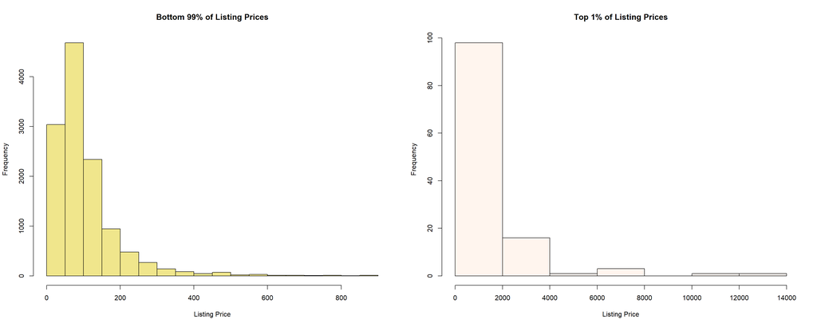

```r
# create 1x2 figure
par(mfrow=c(1,2))

# plot histogram of bottom 99% of listing prices
hist(listings$price[listings$price <= 900],
     main = "Bottom 99% of Listing Prices",
     xlab = "Listing Price",
     ylab = "Frequency",
     col = "khaki")

# plot histogram of top 1% of listing prices
hist(listings$price[listings$price > 900],
     main = "Top 1% of Listing Prices",
     xlab = "Listing Price",
     ylab = "Frequency",
     col = "seashell")
```

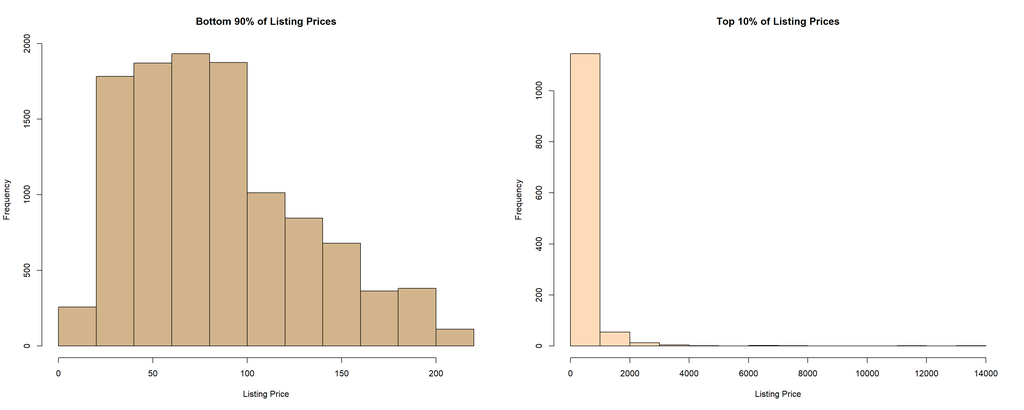

```r
# create 1x2 figure
par(mfrow=c(1,2))

# plot histogram of bottom 90% of listing prices
hist(listings$price[listings$price <= 214],
     main = "Bottom 90% of Listing Prices",
     xlab = "Listing Price",
     ylab = "Frequency",
     col = "tan")

# plot histogram of top 10% of listing prices
hist(listings$price[listings$price > 214],
     main = "Top 10% of Listing Prices",
     xlab = "Listing Price",
     ylab = "Frequency",
     col = "peachpuff")
```

By analyzing these plots above, we can get a good sense of the listings prices available in Montreal. Specifically, we can see why the median value of 85.0 is a much better representation of the average listing price than the mean value of 125.6. Furthermore, it is interesting to see just how such a small number of outliers are able to have such an influence on average price.

Let’s now look at the listing price distributions for different room types as they are likely quite different.

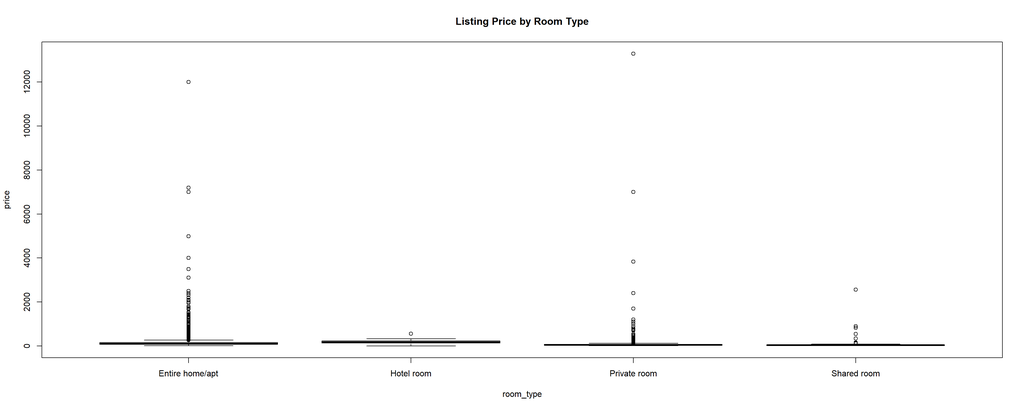

```r
# boxplot listing price by room type
boxplot(price ~ room_type, data = listings,
        main = "Listing Price by Room Type")
```

Again, the outliers in this dataset make these graphs a little difficult to interpret, so let’s look at different percentiles.

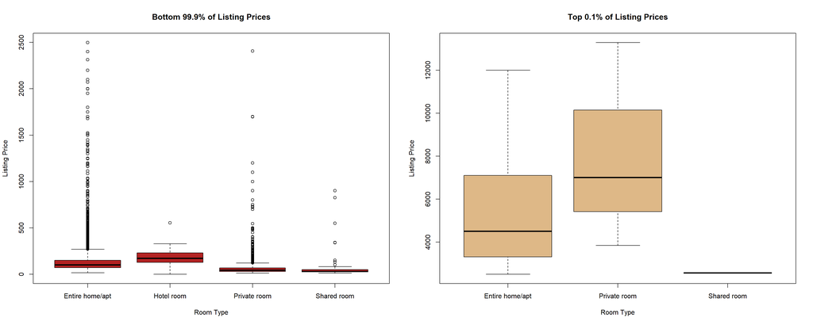

```r
# create 1x2 figure
par(mfrow=c(1,2))

# boxplot bottom 99.9% of listing prices by room type
boxplot(price ~ room_type, data = listings[listings$price <= 2499,],
        main = "Bottom 99.9% of Listing Prices",
        xlab = "Room Type",
        ylab = "Listing Price",
        col = "firebrick")

# boxplot top 0.1% of listing prices by room type
boxplot(price ~ room_type, data = listings[listings$price > 2499,],
        main = "Top 0.1% of Listing Prices",
        xlab = "Room Type",
        ylab = "Listing Price",
        col = "burlywood")
```

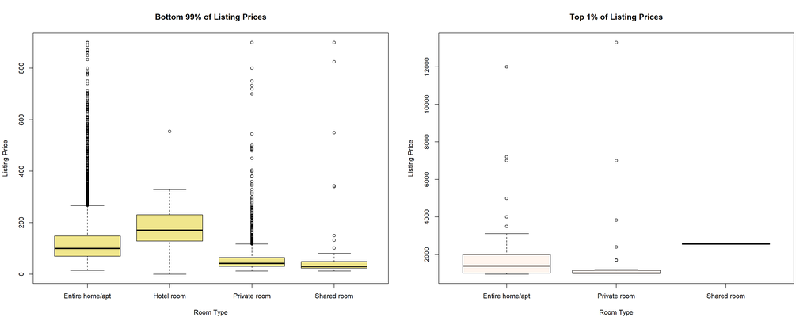

```r
# create 1x2 figure
par(mfrow=c(1,2))

# boxplot bottom 99% of listing prices by room type
boxplot(price ~ room_type, data = listings[listings$price <= 900,],
        main = "Bottom 99% of Listing Prices",
        xlab = "Room Type",
        ylab = "Listing Price",
        col = "khaki")

# boxplot top 1% of listing prices by room type
boxplot(price ~ room_type, data = listings[listings$price > 900,],
        main = "Top 1% of Listing Prices",
        xlab = "Room Type",
        ylab = "Listing Price",
        col = "seashell")
```

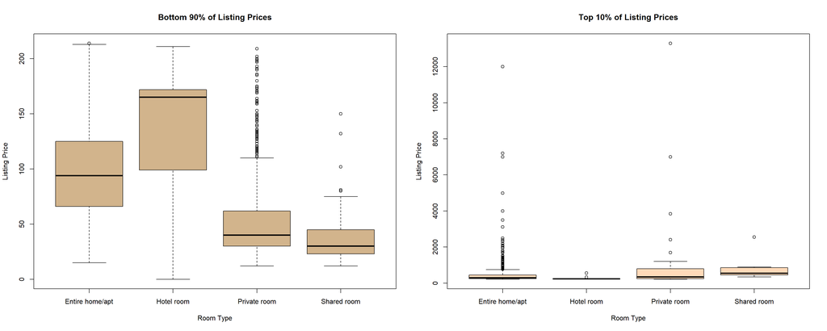

```r
# create 1x2 figure
par(mfrow=c(1,2))

# boxplot bottom 90% of listing prices by room type
boxplot(price ~ room_type, data = listings[listings$price <= 214,],
        main = "Bottom 90% of Listing Prices",
        xlab = "Room Type",
        ylab = "Listing Price",
        col = "tan")

# boxplot top 10% of listing prices by room type
boxplot(price ~ room_type, data = listings[listings$price > 214,],
        main = "Top 10% of Listing Prices",
        xlab = "Room Type",
        ylab = "Listing Price",
        col = "peachpuff")
```

Some interesting conclusions can be drawn from these plots, for example, hotels are the most expensive of the bottom 99.9% of listings but none can be found in the top 1%. Furthermore, shared rooms are the most economical approach of the bottom 90% on average with a mean price of under 50.

Now let’s see where these listings can be found geographically.

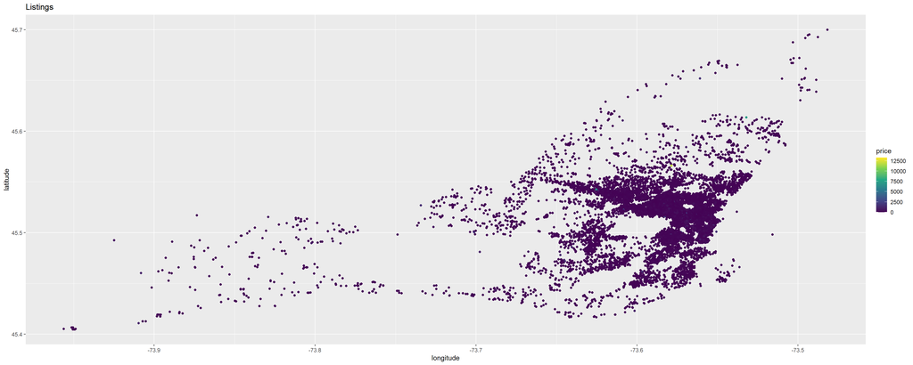

```r
# plot latitude vs longitude with color scale of listing price
ggplot(listings, aes(longitude, latitude)) +
  geom_point(aes(color = price)) +
  scale_color_viridis_c() +
  ggtitle("Listings")
```

Again, the outliers make it different to analyze the plot so let’s take a look at the different percentiles.

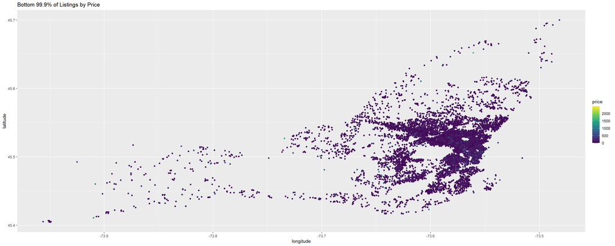

```r
# create 1x2 figure
par(mfrow=c(1,2))

# plot latitude vs longitude of bottom 99.9% with color scale of listing price
ggplot(listings[listings$price <= 2499,], aes(longitude, latitude)) +
  geom_point(aes(color = price)) +
  scale_color_viridis_c() +
  ggtitle("Bottom 99.9% of Listings by Price")
```

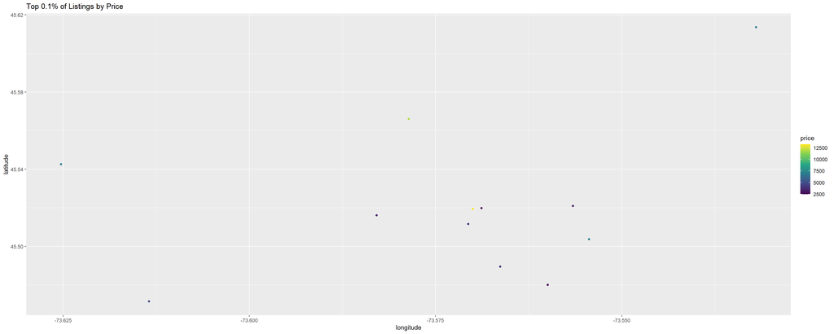

```r
# plot latitude vs longitude of top 0.1% with color scale of listing price
ggplot(listings[listings$price > 2499,], aes(longitude, latitude)) +
  geom_point(aes(color = price)) +
  scale_color_viridis_c() +
  ggtitle("Top 0.1% of Listings by Price")
```

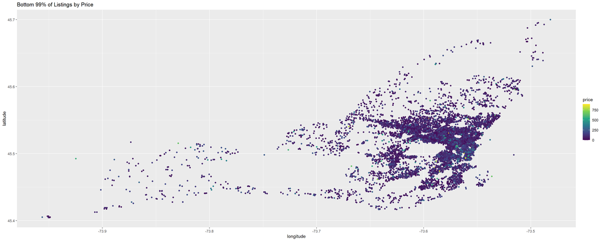

```r
# create 1x2 figure
par(mfrow=c(1,2))

# plot latitude vs longitude of bottom 99% with color scale of listing price
ggplot(listings[listings$price <= 900,], aes(longitude, latitude)) +
  geom_point(aes(color = price)) +
  scale_color_viridis_c() +
  ggtitle("Bottom 99% of Listings by Price")
```

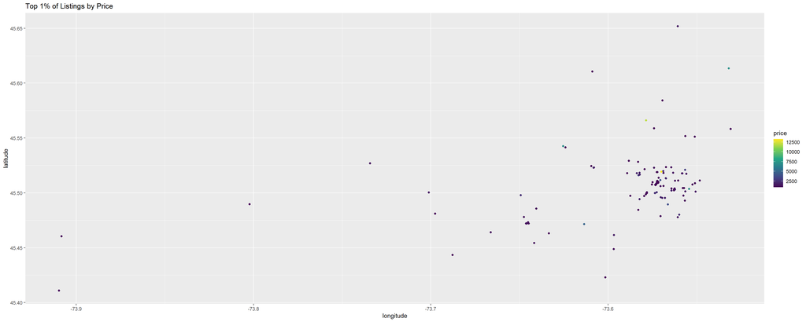

```r
# plot latitude vs longitude of top 1% with color scale of listing price
ggplot(listings[listings$price > 900,], aes(longitude, latitude)) +
  geom_point(aes(color = price)) +
  scale_color_viridis_c() +
  ggtitle("Top 1% of Listings by Price")
```

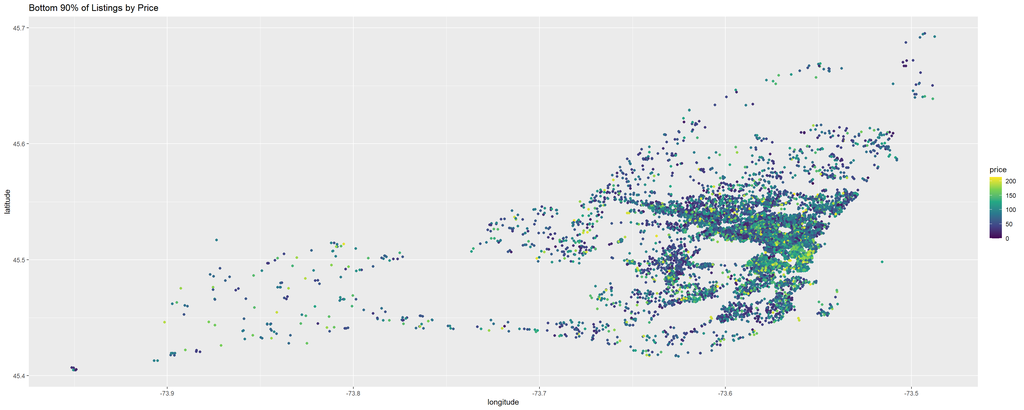

```r
# create 1x2 figure
par(mfrow=c(1,2))

# plot latitude vs longitude of bottom 90% with color scale of listing price
ggplot(listings[listings$price <= 214,], aes(longitude, latitude)) +
  geom_point(aes(color = price)) +
  scale_color_viridis_c() +
  ggtitle("Bottom 90% of Listings by Price")
```

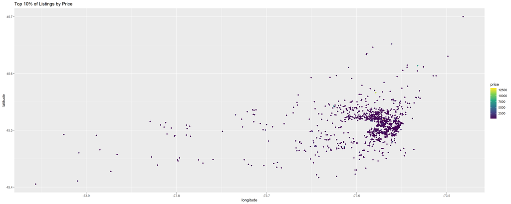

```r
# plot latitude vs longitude of top 10% with color scale of listing price
ggplot(listings[listings$price > 214,], aes(longitude, latitude)) +
  geom_point(aes(color = price)) +
  scale_color_viridis_c() +
  ggtitle("Top 10% of Listings by Price")
```

At this view it is difficult to determine if there is any relation between location and price. Perhaps this can be investigated further with a correlation analysis in RQ4.

## RQ2: Statistical Hypothesis Test 1

### Question

Can room type predict listing price?

### Null Hypothesis (H0)

Room type has no effect on listing price.

### Experiment

A Kruskal–Wallis one-way analysis of variance test can be performed to answer this question as it is an effective method to determine if there are any statistically significant differences between two or more non-parametric groups.

```r
# Kruskal–Wallis one-way analysis of variance test
df1 = data.frame(listings)
df1 = df1[c("room_type", "price")]
kw_results1 <- kruskal.test(price ~ room_type, data = df1)
kw_results1
```

```
##
##  Kruskal-Wallis rank sum test
##
## data:  price by room_type
## Kruskal-Wallis chi-squared = 3147.5, df = 3, p-value < 2.2e-16
```

### Results

As can be seen from the Kruskal–Wallis one-way analysis of variance test results, the p value is less than 2.2e-16; hence, we can reject the null hypothesis and accurately say that room type has an effect on listing price.

## RQ3: Statistical Hypothesis Test 2

### Question

Can neighbourhood predict listing price?

### Null Hypothesis (H0)

Neighbourhood has no effect on listing price.

### Experiment

A Kruskal–Wallis one-way analysis of variance test can be performed to answer this question as it is an effective method to determine if there are any statistically significant differences between two or more non-parametric groups.

```r
# Kruskal–Wallis one-way analysis of variance test
df2 = data.frame(listings)
df2 = df2[c("neighbourhood", "price")]
kw_results2 <- kruskal.test(price ~ neighbourhood, data = df2)
kw_results2
```

```
##
##  Kruskal-Wallis rank sum test
##
## data:  price by neighbourhood
## Kruskal-Wallis chi-squared = 656.79, df = 31, p-value < 2.2e-16
```

### Results

As can be seen from the summary of the Kruskal–Wallis one-way analysis of variance test results, the p value is less than 2.2e-16; hence, we can reject the null hypothesis and accurately say that neighbourhood has an effect on listing price.

## RQ4: Correlation Analysis

### Correlation Analysis 1

Going back to the exploratory analysis performed in RQ1, the first correlation analysis I would like to perform is the correlation between listing location and price. More specifically, I will perform a correlation analysis separately for latitude and longitude. I believe these attributes are interesting to analyze because perhaps it can be determined where one should focus their search when looking for a cheap place to stay in Montreal.

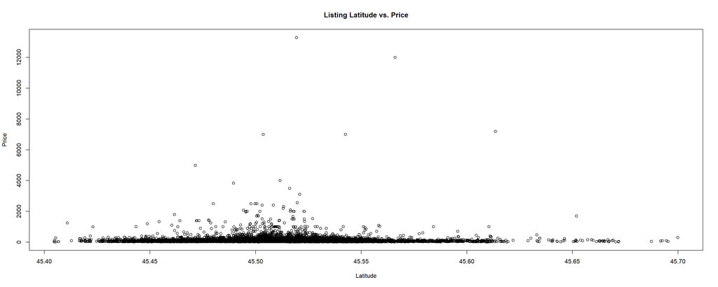

```r
# plot listing latitude vs price
plot(listings$latitude, listings$price,
     main = "Listing Latitude vs. Price",
     xlab = "Latitude",
     ylab = "Price")
```

```r
# correlation between listing latitude and price
cor(listings$latitude, listings$price, use = "complete.obs")
```

```
## [1] -0.02759566
```

As can be seen above in the plot and in the correlation calculation, there is no correlation between listing latitude and price.

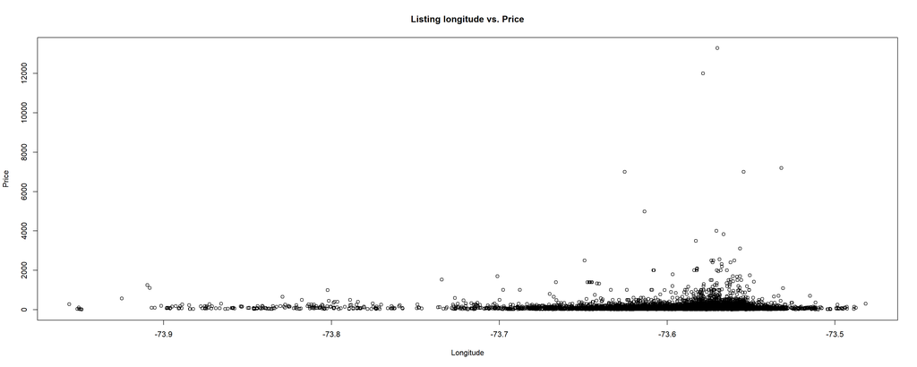

```r
# plot listing longitude vs price
plot(listings$longitude, listings$price,
     main = "Listing longitude vs. Price",
     xlab = "Longitude",
     ylab = "Price")
```

```r
# correlation between listing longitude and price
cor(listings$longitude, listings$price, use = "complete.obs")
```

```
## [1] 0.02076558
```

As can be seen above in the plot and in the correlation calculation, there is no correlation between listing longitude and price.

It is possible; however, that the lack of correlation is due to the fact that the listings data is filled with many different room types. Perhaps if we investigate the relationship between each individual room type and the listing price something will be found.

```r
# get 'Entire home/apt' data
homes <- listings[listings$room_type == "Entire home/apt",]
```

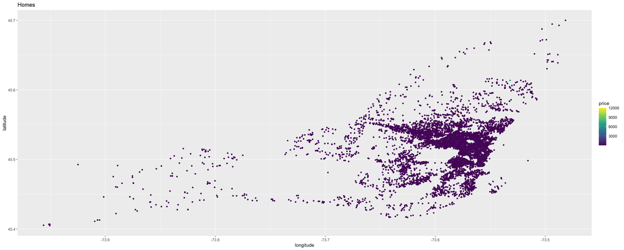

```r
# plot latitude vs longitude of homes with color scale of listing price
ggplot(homes, aes(longitude, latitude)) +
  geom_point(aes(color = price)) +
  scale_color_viridis_c() +
  ggtitle("Homes")
```

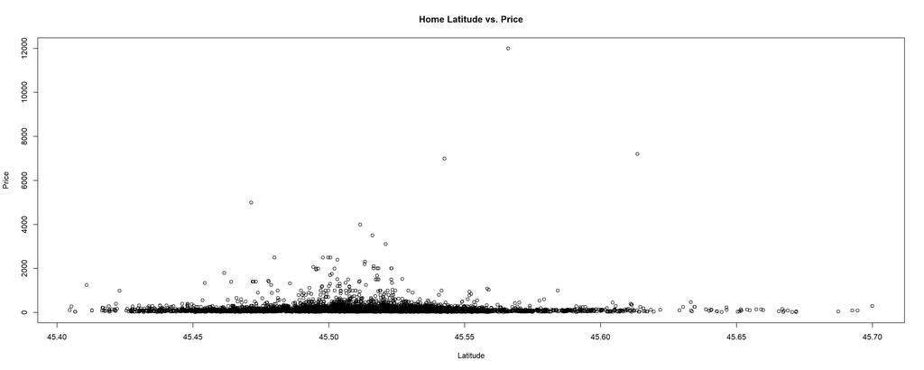

```r
# plot home latitude vs price
plot(homes$latitude, homes$price,
     main = "Home Latitude vs. Price",
     xlab = "Latitude",
     ylab = "Price")
```

```r
# correlation between home latitude and price
cor(homes$latitude, homes$price, use = "complete.obs")
```

```
## [1] -0.02549024
```

As can be seen above in the plot and in the correlation calculation, there is no correlation between home latitude and price.

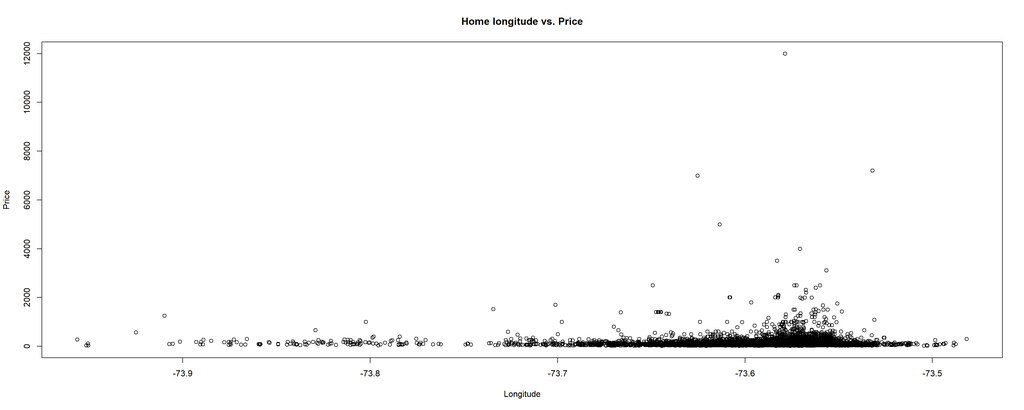

```r
# plot home longitude vs price
plot(homes$longitude, homes$price,
     main = "Home longitude vs. Price",
     xlab = "Longitude",
     ylab = "Price")
```

```r
# correlation between listing longitude and price
cor(homes$longitude, homes$price, use = "complete.obs")
```

```
## [1] 0.01465641
```

As can be seen above in the plot and in the correlation calculation, there is no correlation between home longitude and price.

```r
# get 'Hotel room' data
hotels <- listings[listings$room_type == "Hotel room",]
```

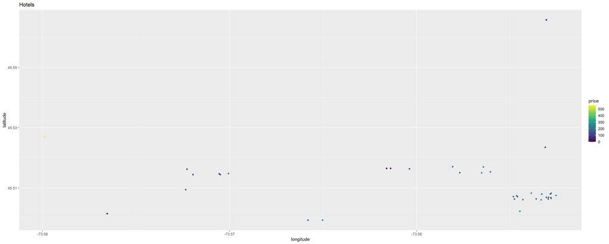

```r
# plot latitude vs longitude of hotels with color scale of listing price
ggplot(hotels, aes(longitude, latitude)) +
  geom_point(aes(color = price)) +
  scale_color_viridis_c() +
  ggtitle("Hotels")
```

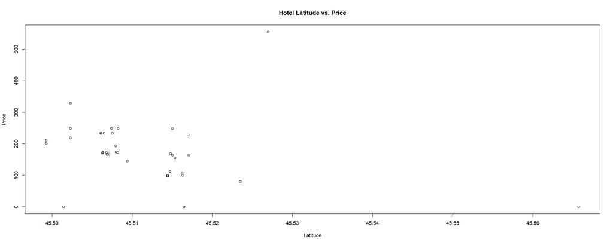

```r
# plot hotels latitude vs price
plot(hotels$latitude, hotels$price,
     main = "Hotel Latitude vs. Price",
     xlab = "Latitude",
     ylab = "Price")
```

```r
# correlation between hotel latitude and price
cor(hotels$latitude, hotels$price, use = "complete.obs")
```

```
## [1] -0.2545042
```

As can be seen above in the plot and in the correlation calculation, there is a weak negative correlation between hotel latitude and price.

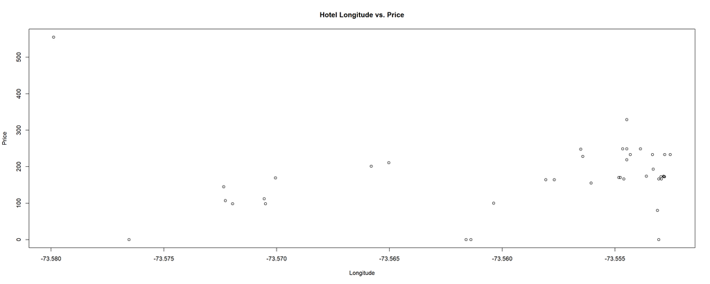

```r
# plot hotels longitude vs price
plot(hotels$longitude, hotels$price,
     main = "Hotel Longitude vs. Price",
     xlab = "Longitude",
     ylab = "Price")
```

```r
# correlation between hotels longitude and price
cor(hotels$longitude, hotels$price, use = "complete.obs")
```

```
## [1] 0.0480779
```

As can be seen above in the plot and in the correlation calculation, there is no correlation between hotel longitude and price.

```r
# get 'Private room' data
singles <- listings[listings$room_type == "Private room",]
```

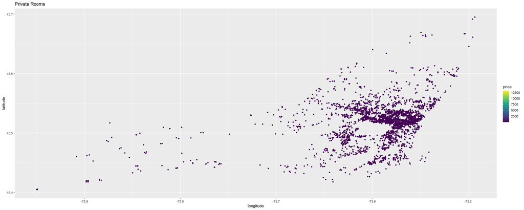

```r
# plot latitude vs longitude of private rooms with color scale of listing price
ggplot(singles, aes(longitude, latitude)) +
  geom_point(aes(color = price)) +
  scale_color_viridis_c() +
  ggtitle("Private Rooms")
```

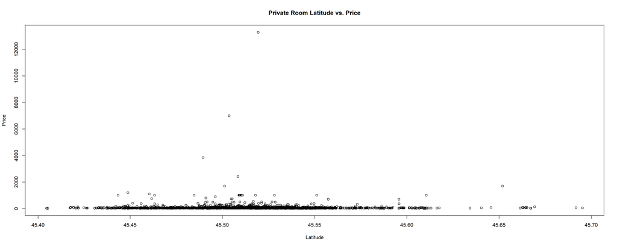

```r
# plot single room latitude vs price
plot(singles$latitude, singles$price,
     main = "Private Room Latitude vs. Price",
     xlab = "Latitude",
     ylab = "Price")
```

```r
# correlation between private room latitude and price
cor(singles$latitude, singles$price, use = "complete.obs")
```

```
## [1] -0.01865665
```

As can be seen above in the plot and in the correlation calculation, there is no correlation between private room latitude and price.

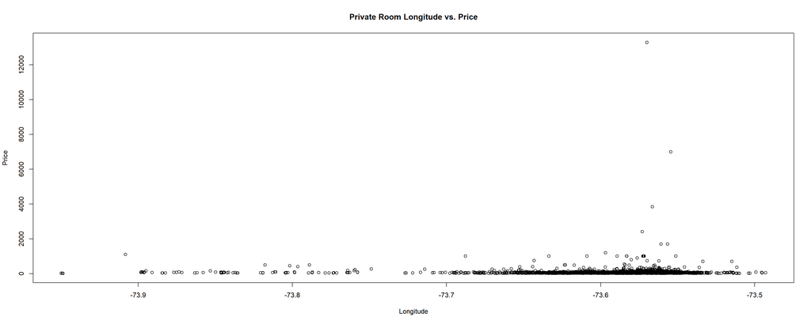

```r
# plot private room longitude vs price
plot(singles$longitude, singles$price,
     main = "Private Room Longitude vs. Price",
     xlab = "Longitude",
     ylab = "Price")
```

```r
# correlation between private room longitude and price
cor(singles$longitude, singles$price, use = "complete.obs")
```

```
## [1] 0.01400444
```

As can be seen above in the plot and in the correlation calculation, there is no correlation between private room longitude and price.

```r
# get 'Shared room' data
shared <- listings[listings$room_type == "Shared room",]
```

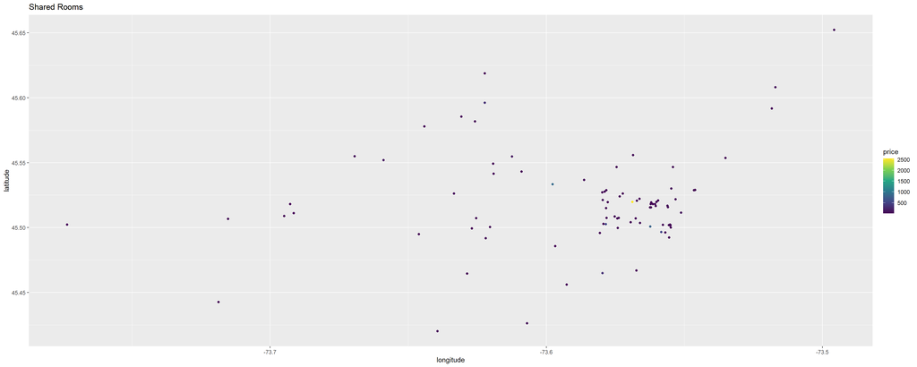

```r
# plot latitude vs longitude of shared rooms with color scale of listing price
ggplot(shared, aes(longitude, latitude)) +
  geom_point(aes(color = price)) +
  scale_color_viridis_c() +
  ggtitle("Shared Rooms")
```

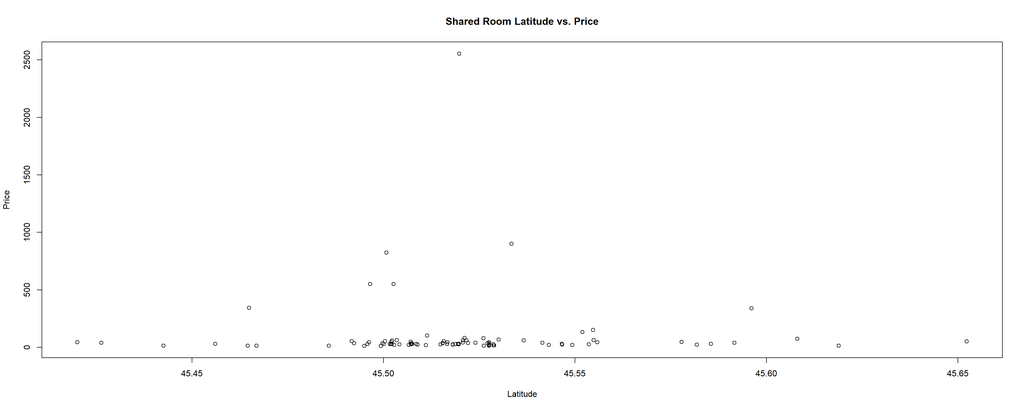

```r
# plot shared room latitude vs price
plot(shared$latitude, shared$price,
     main = "Shared Room Latitude vs. Price",
     xlab = "Latitude",
     ylab = "Price")
```

```r
# correlation between shared room latitude and price
cor(shared$latitude, shared$price, use = "complete.obs")
```

```
## [1] -0.005773422
```

As can be seen above in the plot and in the correlation calculation, there is no correlation between shared room latitude and price.

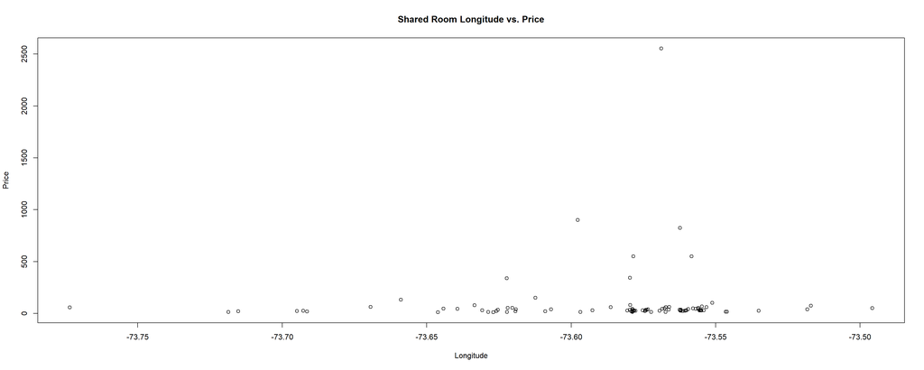

```r
# plot shared room longitude vs price
plot(shared$longitude, shared$price,
     main = "Shared Room Longitude vs. Price",
     xlab = "Longitude",
     ylab = "Price")
```

```r
# correlation between shared room longitude and price
cor(shared$longitude, shared$price, use = "complete.obs")
```

```
## [1] 0.05689514
```

As can be seen above in the plot and in the correlation calculation, there is no correlation between shared room longitude and price.

From the analysis above, it appears that in general there is no correlation between latitude and listing price or longitude and listing price; however, there is a weak negative correlation between hotel latitude and price so if you’re looking for a cheap hotel in Montreal, look north!